# F015011

### Number of Epochs

The following experiment seeks to explore the relationship between the number of epochs our AlexNet implementation is trained for in order to determine the optimal range for training.

**Number of Epochs = 3**

```python
num_epochs = 3
lr = 0.025
momentum = 0.9
batch_size = 256
optimizer_name = 'SGD'
trainloader, valloader, testloader, classes = load_data(batch_size)
alex_net_d = AlexNet(dropout_rate=0.5)
trained_alexnet_3d, training_loss_3d, training_acc_3d, testing_loss_3d, testing_acc_3d = fit_model(alex_net_d, num_epochs, lr, momentum, optimizer_name, trainloader, valloader)
```

```
Files already downloaded and verified
Files already downloaded and verified
```

```
+-------+---------------+-----------------+-------------------+---------------------+
| Epoch | Training Loss | Validation Loss | Training Accuracy | Validation Accuracy |
+-------+---------------+-----------------+-------------------+---------------------+
|   1   |     2.3008    |      2.2879     |       11.30%      |        12.27%       |
|   2   |     2.0757    |      1.8701     |       20.38%      |        26.63%       |
|   3   |     1.7137    |      1.5702     |       32.97%      |        39.27%       |
+-------+---------------+-----------------+-------------------+---------------------+
```

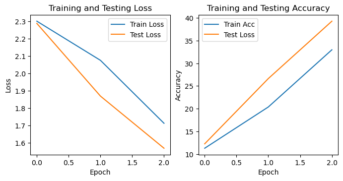

```python
plot_results(training_loss_3d, testing_loss_3d, training_acc_3d, testing_acc_3d)
```

```
Accuracy of the network on the 40000 test images: 39.69%
Weighted F1 score: 0.37
Weighted precision: 0.41
Weighted recall: 0.40
```

```
(39.69, 0.37270500171419263, 0.41269731526766135, 0.3969)
```

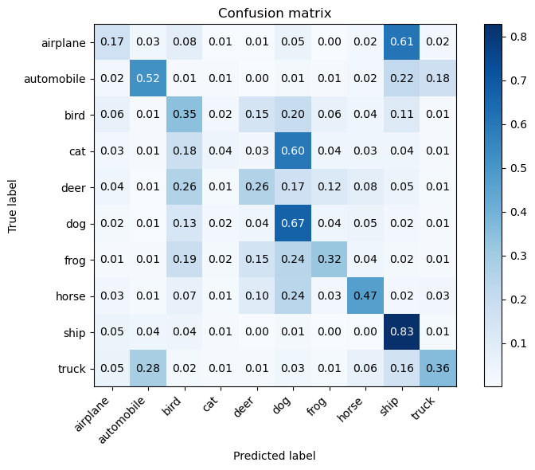

```python
test_model(trained_alexnet_3d, trainloader)
```

**Number of Epochs = 6**

```python
num_epochs = 6
lr = 0.025
momentum = 0.9
batch_size = 256
optimizer_name = 'SGD'
trainloader, valloader, testloader, classes = load_data(batch_size)
alex_net_f = AlexNet(dropout_rate=0.5)
trained_alexnet_3f, training_loss_3f, training_acc_3f, testing_loss_3f, testing_acc_3f = fit_model(alex_net_f, num_epochs, lr, momentum, optimizer_name, trainloader, valloader)
```

```
Files already downloaded and verified
Files already downloaded and verified
```

```
+-------+---------------+-----------------+-------------------+---------------------+
| Epoch | Training Loss | Validation Loss | Training Accuracy | Validation Accuracy |
+-------+---------------+-----------------+-------------------+---------------------+
|   1   |     2.3001    |      2.2688     |       10.57%      |        13.51%       |
|   2   |     2.0173    |      1.8560     |       21.62%      |        28.17%       |
|   3   |     1.6946    |      1.5961     |       34.31%      |        35.98%       |
|   4   |     1.4446    |      1.3307     |       45.33%      |        50.96%       |
|   5   |     1.2663    |      1.2671     |       52.98%      |        54.72%       |
|   6   |     1.1200    |      1.1184     |       59.01%      |        59.50%       |
+-------+---------------+-----------------+-------------------+---------------------+
```

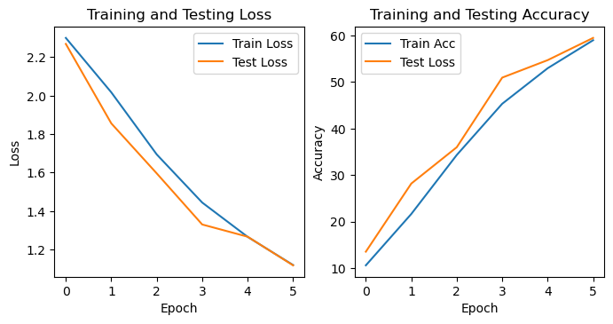

```python
plot_results(training_loss_3f, testing_loss_3f, training_acc_3f, testing_acc_3f)
```

```
Accuracy of the network on the 40000 test images: 62.49%
Weighted F1 score: 0.61
Weighted precision: 0.63
Weighted recall: 0.62
```

```
(62.4925, 0.6123552824127692, 0.6304742419888123, 0.624925)
```

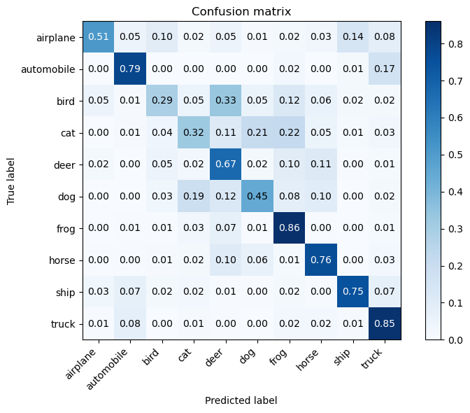

```python
test_model(trained_alexnet_3f, trainloader)
```

**Number of Epochs = 24**

```python
num_epochs = 24
lr = 0.025
momentum = 0.9
batch_size = 256
optimizer_name = 'SGD'
trainloader, valloader, testloader, classes = load_data(batch_size)
alex_net_e = AlexNet(dropout_rate=0.5)
trained_alexnet_3e, training_loss_3e, training_acc_3e, testing_loss_3e, testing_acc_3e = fit_model(alex_net_e, num_epochs, lr, momentum, optimizer_name, trainloader, valloader)
```

```
Files already downloaded and verified
Files already downloaded and verified
```

```
+-------+---------------+-----------------+-------------------+---------------------+
| Epoch | Training Loss | Validation Loss | Training Accuracy | Validation Accuracy |
+-------+---------------+-----------------+-------------------+---------------------+
|   1   |     2.2987    |      2.2503     |       11.32%      |        12.55%       |
|   2   |     1.9611    |      1.8934     |       22.96%      |        29.65%       |
|   3   |     1.6539    |      1.5006     |       35.91%      |        43.43%       |
|   4   |     1.4264    |      1.3417     |       46.47%      |        50.14%       |
|   5   |     1.2530    |      1.2239     |       54.05%      |        55.57%       |
|   6   |     1.0976    |      1.0950     |       60.17%      |        60.09%       |
|   7   |     0.9876    |      0.9822     |       64.56%      |        64.16%       |
|   8   |     0.8534    |      0.9591     |       69.41%      |        66.08%       |
|   9   |     0.7654    |      0.9311     |       72.58%      |        67.93%       |
|   10  |     0.6682    |      0.9782     |       76.44%      |        67.35%       |
|   11  |     0.5796    |      1.0023     |       79.45%      |        67.47%       |
|   12  |     0.5036    |      0.8754     |       82.03%      |        71.96%       |
|   13  |     0.4138    |      0.9003     |       85.19%      |        70.87%       |
|   14  |     0.3444    |      0.9508     |       87.75%      |        72.25%       |
|   15  |     0.2849    |      1.0548     |       89.91%      |        71.93%       |
|   16  |     0.2431    |      1.0255     |       91.44%      |        71.69%       |
|   17  |     0.2106    |      1.1239     |       92.67%      |        70.36%       |
|   18  |     0.1672    |      1.1818     |       94.14%      |        71.75%       |
|   19  |     0.1347    |      1.2572     |       95.29%      |        72.40%       |
|   20  |     0.1103    |      1.3581     |       96.13%      |        71.72%       |
|   21  |     0.1052    |      1.4516     |       96.30%      |        70.80%       |
|   22  |     0.0806    |      1.4095     |       97.16%      |        71.56%       |
|   23  |     0.0722    |      1.4282     |       97.43%      |        71.07%       |
|   24  |     0.0710    |      1.4533     |       97.63%      |        72.80%       |
+-------+---------------+-----------------+-------------------+---------------------+
```

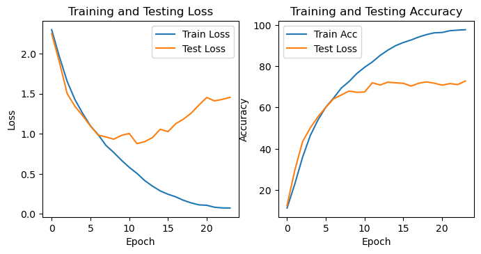

```python
plot_results(training_loss_3e, testing_loss_3e, training_acc_3e, testing_acc_3e)
```

```
Accuracy of the network on the 40000 test images: 93.35%
Weighted F1 score: 0.93
Weighted precision: 0.93
Weighted recall: 0.93
```

```
(93.35, 0.9335232205511753, 0.9339609098788293, 0.9335)
```

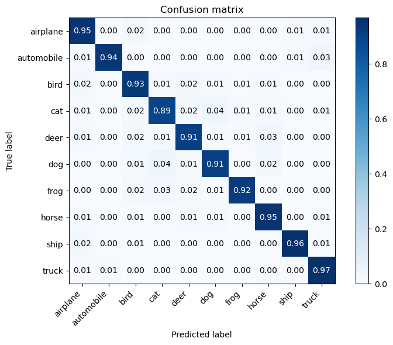

```python
test_model(trained_alexnet_3e, trainloader)
```

## Conclusion

In conclusion, this notebook presented an extensive experiment with three different convolutional network architectures and two different configuration parameters to classify the CIFAR-10 dataset. Through the analysis of various visualisations, including loss graphs and confusion matrices, we gained insights into the performance of these models. Our experimentation has provided us with a deeper understanding of the effectiveness of different convolutional neural network architectures and configuration parameters for classification tasks. A summary of the optimal values found is as follows:

| Learning Rate | Batch Size | Optimizer Algorithm | Momentum Rate | Dropout Rate | Epochs |
| --- | --- | --- | --- | --- | --- |
| 0.025 | 256 | SGD | 0.9 | 0.5 | 12 |